# Lab 2: Classification

## Classification - Model Selection

```python
# Function to report model summaries.
def model_report(model_name, model):
    print('\nSearch for OPTIMAL THRESHOLD, vary from 0.0001 to 0.9999, fit/predict on train/test data')
    model.fit(X_train, y_train)
    optimal_th = 0.5   # start with default threshold value

    for i in range(0,3):
        score_list = []
        print('\nLooping decimal place', i+1)
        th_list = [np.linspace(optimal_th-0.4999, optimal_th+0.4999, 11),
                  # eg [ 0.0001 , 0.1008, 0.2006, 0.3004, 0.4002, 0.5, 0.5998, 0.6996, 0.7994, 0.8992, 0.9999 ]
                 np.linspace(optimal_th-0.1, optimal_th+0.1, 21),
                  # eg 0.3xx [ 0.2 , 0.21, 0.22, 0.23, 0.24, 0.25, 0.26, 0.27, 0.28, 0.29, 0.3 , 0.31, 0.32, 0.33, 0.34, 0.35, 0.36, 0.37, 0.38, 0.39, 0.4 ]
                 np.linspace(optimal_th-0.01, optimal_th+0.01, 21)]
                  # eg 0.30x [ 0.29 , 0.291, 0.292, 0.293, 0.294, 0.295, 0.296, 0.297, 0.298, 0.299, 0.3  , 0.301, 0.302, 0.303, 0.304, 0.305, 0.306, 0.307, 0.308, 0.309, 0.31 ]
        for th in th_list[i]:
            y_pred = (model.predict_proba(X_test)[:,1] >= th)
            f1scor = f1_score(y_test, y_pred)
            score_list.append(f1scor)
            print('{:.3f}->{:.4f}'.format(th, f1scor), end=',  ')   # display score in 4 decimal pl
        optimal_th = float(th_list[i][score_list.index(max(score_list))])

    print('optimal F1 score = {:.4f}'.format(max(score_list)))
    print('optimal threshold = {:.3f}'.format(optimal_th))

    print(model_name, 'accuracy score is')
    print('Training: {:.2f}%'.format(100*model.score(X_train, y_train)))  # score uses accuracy
    print('Test set: {:.2f}%'.format(100*model.score(X_test, y_test)))   # should use cross validation

    y_pred = (model.predict_proba(X_test)[:,1] >= 0.25)
    print('\nAdjust threshold to 0.25:')
    print('Precision: {:.4f},   Recall: {:.4f},   F1 Score: {:.4f}'.format(
        precision_score(y_test, y_pred), recall_score(y_test, y_pred), f1_score(y_test, y_pred)))
    print(model_name, 'confusion matrix: \n', confusion_matrix(y_test, y_pred))

    y_pred = model.predict(X_test)
    print('\nDefault threshold of 0.50:')
    print('Precision: {:.4f},   Recall: {:.4f},   F1 Score: {:.4f}'.format(
        precision_score(y_test, y_pred), recall_score(y_test, y_pred), f1_score(y_test, y_pred)))
    print(model_name, 'confusion matrix: \n', confusion_matrix(y_test, y_pred))

    y_pred = (model.predict_proba(X_test)[:,1] >= 0.75)
    print('\nAdjust threshold to 0.75:')
    print('Precision: {:.4f},   Recall: {:.4f},   F1 Score: {:.4f}'.format(
        precision_score(y_test, y_pred), recall_score(y_test, y_pred), f1_score(y_test, y_pred)))
    print(model_name, 'confusion matrix: \n', confusion_matrix(y_test, y_pred))

    y_pred = (model.predict_proba(X_test)[:,1] >= optimal_th)
    print('\nOptimal threshold {:.3f}'.format(optimal_th))
    print('Precision: {:.4f},   Recall: {:.4f},   F1 Score: {:.4f}'.format(
        precision_score(y_test, y_pred), recall_score(y_test, y_pred), f1_score(y_test, y_pred)))
    print(model_name, 'confusion matrix: \n', confusion_matrix(y_test, y_pred))

    global model_f1, model_auc, model_ll, model_roc_auc
    model_f1 = f1_score(y_test, y_pred)

    y_pred = model.predict_proba(X_test)
    model_ll = log_loss(y_test, y_pred)
    print(model_name, 'Log-loss: {:.4f}'.format(model_ll))
    y_pred = model.predict(X_test)
    model_roc_auc = roc_auc_score(y_test, y_pred)
    print(model_name, 'roc_auc_score: {:.4f}'.format(model_roc_auc))
    y_pred = model.predict_proba(X_test)[:,1]
    fpr, tpr, thresholds = roc_curve(y_test, y_pred)
    model_auc = auc(fpr, tpr)
    print(model_name, 'AUC: {:.4f}'.format(model_auc))

    # plot the ROC curve
    plt.figure(figsize = [6,6])
    plt.plot(fpr, tpr, label='ROC curve (area = %0.2f)' % model_auc)
    plt.plot([0, 1], [0, 1],'r--')
    plt.xlim([0.0, 1.0])
    plt.ylim([0.0, 1.0])
    plt.xlabel('False Positive Rate')
    plt.ylabel('True Positive Rate')
    plt.title('Receiver Operating Characteristic')
    plt.legend(loc="lower right")
    # plt.savefig('roc_auc_score')
    plt.show()

    return

# initialise lists to collect the results to plot later
model_list = []
f1_list = []
auc_list = []
ll_list = []
roc_auc_list = []
time_list = []
```

```
"""""" GaussianNB """"""

Search for OPTIMAL THRESHOLD, vary from 0.0001 to 0.9999, fit/predict on train/test data

Looping decimal place 1
0.000->0.5823,  0.100->0.6149,  0.200->0.6179,  0.300->0.6211,  0.400->0.6197,  0.500->0.6136,  0.600->0.6151,  0.700->0.6193,  0.800->0.6176,  0.900->0.6173,  1.000->0.5064,
Looping decimal place 2
0.200->0.6179,  0.210->0.6179,  0.220->0.6177,  0.230->0.6184,  0.240->0.6190,  0.250->0.6203,  0.260->0.6195,  0.270->0.6200,  0.280->0.6186,  0.290->0.6198,  0.300->0.6211,  0.310->0.6197,  0.320->0.6197,  0.330->0.6210,  0.340->0.6202,  0.350->0.6202,  0.360->0.6202,  0.370->0.6194,  0.380->0.619…
Looping decimal place 3
0.290->0.6198,  0.291->0.6198,  0.292->0.6198,  0.293->0.6198,  0.294->0.6205,  0.295->0.6205,  0.296->0.6205,  0.297->0.6205,  0.298->0.6211,  0.299->0.6211,  0.300->0.6211,  0.301->0.6211,  0.302->0.6211,  0.303->0.6211,  0.304->0.6197,  0.305->0.6197,  0.306->0.6197,  0.307->0.6197,  0.308->0.619…
optimal threshold = 0.298
GaussianNB accuracy score is
Training: 76.09%
Test set: 74.17%

Adjust threshold to 0.25:
Precision: 0.5127,   Recall: 0.7850,   F1 Score: 0.6203
GaussianNB confusion matrix:
 [[735 288]
 [ 83 303]]

Default threshold of 0.50:
Precision: 0.5198,   Recall: 0.7487,   F1 Score: 0.6136
GaussianNB confusion matrix:
 [[756 267]
 [ 97 289]]

Adjust threshold to 0.75:
Precision: 0.5368,   Recall: 0.7176,   F1 Score: 0.6142
GaussianNB confusion matrix:
 [[784 239]
 [109 277]]

Optimal threshold 0.298
Precision: 0.5172,   Recall: 0.7772,   F1 Score: 0.6211
GaussianNB confusion matrix:
 [[743 280]
 [ 86 300]]
GaussianNB Log-loss: 1.9658
GaussianNB roc_auc_score: 0.7439
GaussianNB AUC: 0.8247
```

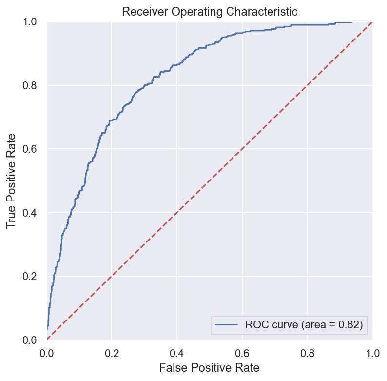

```
"""""" BernoulliNB """"""

Search for OPTIMAL THRESHOLD, vary from 0.0001 to 0.9999, fit/predict on train/test data

Looping decimal place 1
0.000->0.5067,  0.100->0.6046,  0.200->0.6129,  0.300->0.6099,  0.400->0.6149,  0.500->0.6183,  0.600->0.6047,  0.700->0.5833,  0.800->0.5792,  0.900->0.5587,  1.000->0.0504,
Looping decimal place 2
0.400->0.6149,  0.410->0.6162,  0.420->0.6176,  0.430->0.6203,  0.440->0.6210,  0.450->0.6185,  0.460->0.6168,  0.470->0.6166,  0.480->0.6142,  0.490->0.6149,  0.500->0.6183,  0.510->0.6152,  0.520->0.6150,  0.530->0.6178,  0.540->0.6161,  0.550->0.6152,  0.560->0.6127,  0.570->0.6141,  0.580->0.610…
Looping decimal place 3
0.430->0.6203,  0.431->0.6203,  0.432->0.6203,  0.433->0.6203,  0.434->0.6203,  0.435->0.6203,  0.436->0.6203,  0.437->0.6203,  0.438->0.6203,  0.439->0.6210,  0.440->0.6210,  0.441->0.6210,  0.442->0.6195,  0.443->0.6195,  0.444->0.6186,  0.445->0.6186,  0.446->0.6178,  0.447->0.6178,  0.448->0.617…
optimal threshold = 0.439
BernoulliNB accuracy score is
Training: 77.10%
Test set: 76.08%

Adjust threshold to 0.25:
Precision: 0.5103,   Recall: 0.7668,   F1 Score: 0.6128
BernoulliNB confusion matrix:
 [[739 284]
 [ 90 296]]

Default threshold of 0.50:
Precision: 0.5493,   Recall: 0.7073,   F1 Score: 0.6183
BernoulliNB confusion matrix:
 [[799 224]
 [113 273]]

Adjust threshold to 0.75:
Precision: 0.5680,   Recall: 0.6062,   F1 Score: 0.5865
BernoulliNB confusion matrix:
 [[845 178]
 [152 234]]

Optimal threshold 0.439
Precision: 0.5414,   Recall: 0.7280,   F1 Score: 0.6210
BernoulliNB confusion matrix:
 [[785 238]
 [105 281]]
BernoulliNB Log-loss: 0.9093
BernoulliNB roc_auc_score: 0.7441
BernoulliNB AUC: 0.8155
```

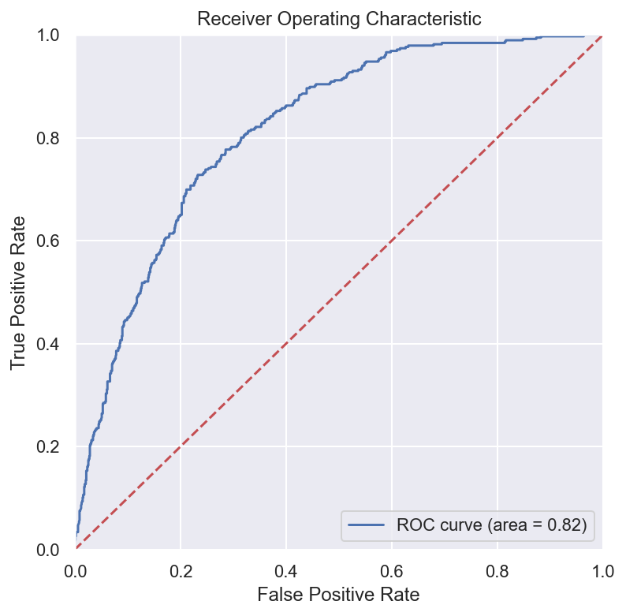

```python
print('\n"""""" GaussianNB """"""')
time1 = time.time()
gnb = GaussianNB()
model_report('GaussianNB', gnb)

model_list.append('GaussianNB')
f1_list.append(model_f1)
auc_list.append(model_auc)
ll_list.append(model_ll)
roc_auc_list.append(model_roc_auc)
time_list.append(time.time() - time1)

print('\n"""""" BernoulliNB """"""')
time1 = time.time()
bnb = BernoulliNB()
model_report('BernoulliNB', bnb)

model_list.append('BernoulliNB')
f1_list.append(model_f1)
auc_list.append(model_auc)
ll_list.append(model_ll)
roc_auc_list.append(model_roc_auc)
time_list.append(time.time() - time1)
```

```
"""""" LogisticRegression """"""

Search for optimal hyperparameter C in LogisticRegresssion, vary C from 0.001 to 1000, using KFold(5) Cross Validation on train data
0.0544, 0.0839, 0.1245, 0.1651, 0.2088, 0.2384, 0.2638, 0.2832, 0.3045, 0.3274, 0.3416, 0.3613, 0.3808, 0.3927, 0.4050, 0.4191, 0.4348, 0.4432, 0.4506, 0.4603, 0.4689, 0.4749, 0.4792, 0.4884, 0.4985, 0.5020, 0.5076, 0.5142, 0.5167, 0.5231, 0.5267, 0.5316, 0.5359, 0.5357, 0.5376, 0.5405, 0.5436, 0.54…
optimal value of C = 378.346

Search for OPTIMAL THRESHOLD, vary from 0.0001 to 0.9999, fit/predict on train/test data

Looping decimal place 1
0.000->0.4301,  0.100->0.5694,  0.200->0.6171,  0.300->0.6327,  0.400->0.6357,  0.500->0.6059,  0.600->0.5277,  0.700->0.3931,  0.800->0.1737,  0.900->0.0000,  1.000->0.0000,
Looping decimal place 2
0.300->0.6327,  0.310->0.6349,  0.320->0.6375,  0.330->0.6364,  0.340->0.6373,  0.350->0.6392,  0.360->0.6450,  0.370->0.6479,  0.380->0.6412,  0.390->0.6410,  0.400->0.6357,  0.410->0.6344,  0.420->0.6317,  0.430->0.6261,  0.440->0.6253,  0.450->0.6220,  0.460->0.6148,  0.470->0.6160,  0.480->0.611…
Looping decimal place 3
0.360->0.6450,  0.361->0.6434,  0.362->0.6434,  0.363->0.6441,  0.364->0.6456,  0.365->0.6456,  0.366->0.6464,  0.367->0.6471,  0.368->0.6479,  0.369->0.6479,  0.370->0.6479,  0.371->0.6447,  0.372->0.6431,  0.373->0.6423,  0.374->0.6430,  0.375->0.6430,  0.376->0.6422,  0.377->0.6405,  0.378->0.641…
optimal threshold = 0.368
LogisticRegression accuracy score is
Training: 80.99%
Test set: 80.06%

Adjust threshold to 0.25:
Precision: 0.5072,   Recall: 0.8187,   F1 Score: 0.6264
LogisticRegression confusion matrix:
 [[716 307]
 [ 70 316]]

Default threshold of 0.50:
Precision: 0.6606,   Recall: 0.5596,   F1 Score: 0.6059
LogisticRegression confusion matrix:
 [[912 111]
 [170 216]]

Adjust threshold to 0.75:
Precision: 0.7935,   Recall: 0.1891,   F1 Score: 0.3054
LogisticRegression confusion matrix:
 [[1004   19]
 [ 313   73]]

Optimal threshold 0.368
Precision: 0.5923,   Recall: 0.7150,   F1 Score: 0.6479
LogisticRegression confusion matrix:
 [[833 190]
 [110 276]]
LogisticRegression Log-loss: 0.4189
LogisticRegression roc_auc_score: 0.7255
LogisticRegression AUC: 0.8468
```

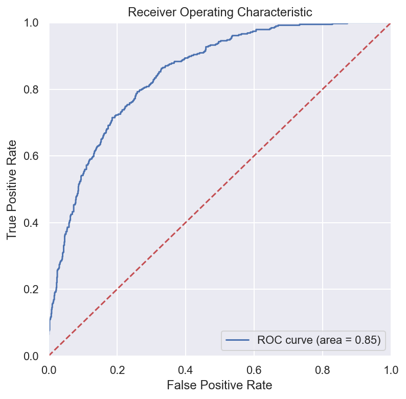

```python
print('\n"""""" LogisticRegression """"""')
print('\nSearch for optimal hyperparameter C in LogisticRegresssion, vary C from 0.001 to 1000, using KFold(5) Cross Validation on train data')
kf = KFold(n_splits=5, random_state=21, shuffle=True)  #produce the k folds
score_list = []
c_list = 10**np.linspace(-3,3,200)
for c in c_list:
    logit = LogisticRegression(C = c)
    cvs = (cross_val_score(logit, X_train, y_train, cv=kf, scoring='f1')).mean()
    score_list.append(cvs)
    print('{:.4f}'.format(cvs), end=", ")   # 4 decimal pl
print('optimal cv F1 score = {:.4f}'.format(max(score_list)))
optimal_c = float(c_list[score_list.index(max(score_list))])
print('optimal value of C = {:.3f}'.format(optimal_c))

time1 = time.time()
logit = LogisticRegression(C = optimal_c)
model_report('LogisticRegression', logit)

model_list.append('LogisticRegression')
f1_list.append(model_f1)
auc_list.append(model_auc)
ll_list.append(model_ll)
roc_auc_list.append(model_roc_auc)
time_list.append(time.time() - time1)
```

```
"""""" KNN """""" (quite slow)

Search for optimal hyperparameter K in KNN, vary K from 1 to 20, using KFold(5) Cross Validation on train data
0.5108, 0.4152, 0.5438, 0.4915, 0.5621, 0.5177, 0.5574, 0.5319, 0.5746, 0.5445, 0.5719, 0.5547, 0.5872, 0.5623, 0.5791, 0.5637, 0.5892, 0.5679, 0.5857, 0.5795, optimal cv F1 score = 0.5892
optimal value of K = 17

Search for OPTIMAL THRESHOLD, vary from 0.0001 to 0.9999, fit/predict on train/test data

Looping decimal place 1
0.000->0.5000,  0.100->0.5484,  0.200->0.5759,  0.300->0.5952,  0.400->0.5893,  0.500->0.5575,  0.600->0.4790,  0.700->0.4014,  0.800->0.2188,  0.900->0.0404,  1.000->0.0052,
Looping decimal place 2
0.200->0.5759,  0.210->0.5759,  0.220->0.5759,  0.230->0.5759,  0.240->0.6017,  0.250->0.6017,  0.260->0.6017,  0.270->0.6017,  0.280->0.6017,  0.290->0.6017,  0.300->0.5952,  0.310->0.5952,  0.320->0.5952,  0.330->0.5952,  0.340->0.5952,  0.350->0.5952,  0.360->0.5893,  0.370->0.5893,  0.380->0.589…
Looping decimal place 3
0.230->0.5759,  0.231->0.5759,  0.232->0.5759,  0.233->0.5759,  0.234->0.5759,  0.235->0.5759,  0.236->0.6017,  0.237->0.6017,  0.238->0.6017,  0.239->0.6017,  0.240->0.6017,  0.241->0.6017,  0.242->0.6017,  0.243->0.6017,  0.244->0.6017,  0.245->0.6017,  0.246->0.6017,  0.247->0.6017,  0.248->0.601…
optimal threshold = 0.236
KNN accuracy score is
Training: 81.84%
Test set: 76.79%

Adjust threshold to 0.25:
Precision: 0.4714,   Recall: 0.8316,   F1 Score: 0.6017
KNN confusion matrix:
 [[663 360]
 [ 65 321]]

Default threshold of 0.50:
Precision: 0.5836,   Recall: 0.5337,   F1 Score: 0.5575
KNN confusion matrix:
 [[876 147]
 [180 206]]

Adjust threshold to 0.75:
Precision: 0.7632,   Recall: 0.2254,   F1 Score: 0.3480
KNN confusion matrix:
 [[996  27]
 [299  87]]

Optimal threshold 0.236
Precision: 0.4714,   Recall: 0.8316,   F1 Score: 0.6017
KNN confusion matrix:
 [[663 360]
 [ 65 321]]
KNN Log-loss: 0.6372
KNN roc_auc_score: 0.6950
KNN AUC: 0.8061
```

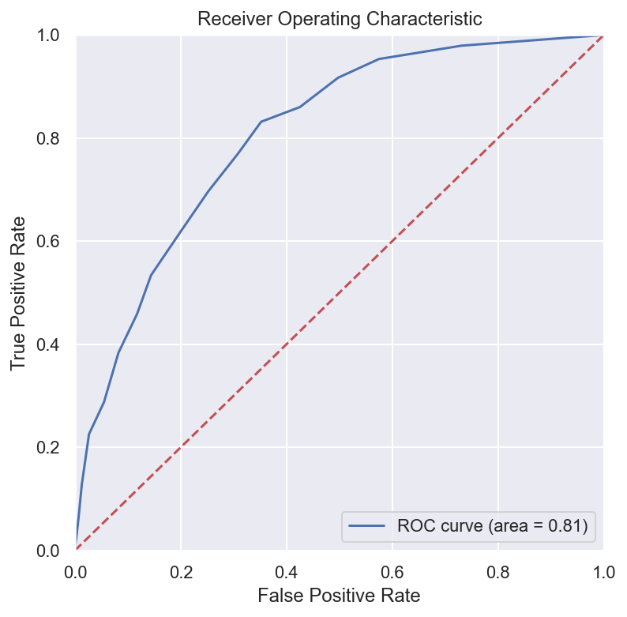

```
Compare with KNN classification_report (same as default threshold 0.50)
              precision    recall  f1-score   support

           0       0.83      0.86      0.84      1023
           1       0.58      0.53      0.56       386

    accuracy                           0.77      1409
   macro avg       0.71      0.69      0.70      1409
weighted avg       0.76      0.77      0.76      1409
```

```python
print('\n"""""" KNN """""" (quite slow)')
print('\nSearch for optimal hyperparameter K in KNN, vary K from 1 to 20, using KFold(5) Cross Validation on train data')
kf = KFold(n_splits=5, random_state=21, shuffle=True)  #produce the k folds
k_scores = []
for k in range(1, 21):
    knn = KNeighborsClassifier(n_neighbors = k)
    cvs = cross_val_score(knn, X_train, y_train, cv=kf, scoring='f1').mean()
    k_scores.append(cvs)
    print('{:.4f}'.format(cvs), end=", ")
print('optimal cv F1 score = {:.4f}'.format(max(k_scores)))   # 4 decimal pl
optimal_k = k_scores.index(max(k_scores))+1   # index 0 is for k=1
print('optimal value of K =', optimal_k)

time1 = time.time()
knn = KNeighborsClassifier(n_neighbors = optimal_k)
model_report('KNN', knn)

print('\nCompare with KNN classification_report (same as default threshold 0.50)')
knn.fit(X_train, y_train)
y_pred = knn.predict(X_test)
print(metrics.classification_report(y_test, y_pred))

model_list.append('KNN')
f1_list.append(model_f1)
auc_list.append(model_auc)
ll_list.append(model_ll)
roc_auc_list.append(model_roc_auc)
time_list.append(time.time() - time1)
```

```
"""""" DecisionTreeClassifier """"""

Search for optimal max_depth in DecisionTree, vary 2 to 10, using KFold(5) Cross Validation on train data
0.5801, 0.4874, 0.5377, 0.5385, 0.5500, 0.5417, 0.5344, 0.5379, 0.5525, optimal F1 score = 0.5801
optimal max_depth = 2

Search for OPTIMAL THRESHOLD, vary from 0.0001 to 0.9999, fit/predict on train/test data

Looping decimal place 1
0.000->0.4301,  0.100->0.5408,  0.200->0.5795,  0.300->0.5837,  0.400->0.5837,  0.500->0.5837,  0.600->0.0000,  0.700->0.0000,  0.800->0.0000,  0.900->0.0000,  1.000->0.0000,
Looping decimal place 2
0.200->0.5795,  0.210->0.5795,  0.220->0.5795,  0.230->0.5795,  0.240->0.5795,  0.250->0.5795,  0.260->0.5795,  0.270->0.5795,  0.280->0.5795,  0.290->0.5837,  0.300->0.5837,  0.310->0.5837,  0.320->0.5837,  0.330->0.5837,  0.340->0.5837,  0.350->0.5837,  0.360->0.5837,  0.370->0.5837,  0.380->0.583…
Looping decimal place 3
0.280->0.5795,  0.281->0.5795,  0.282->0.5837,  0.283->0.5837,  0.284->0.5837,  0.285->0.5837,  0.286->0.5837,  0.287->0.5837,  0.288->0.5837,  0.289->0.5837,  0.290->0.5837,  0.291->0.5837,  0.292->0.5837,  0.293->0.5837,  0.294->0.5837,  0.295->0.5837,  0.296->0.5837,  0.297->0.5837,  0.298->0.583…
optimal threshold = 0.282
DecisionTreeClassifier accuracy score is
Training: 76.30%
Test set: 76.01%

Adjust threshold to 0.25:
Precision: 0.4324,   Recall: 0.8782,   F1 Score: 0.5795
DecisionTreeClassifier confusion matrix:
 [[578 445]
 [ 47 339]]

Default threshold of 0.50:
Precision: 0.5563,   Recall: 0.6140,   F1 Score: 0.5837
DecisionTreeClassifier confusion matrix:
 [[834 189]
 [149 237]]

Adjust threshold to 0.75:
Precision: 0.0000,   Recall: 0.0000,   F1 Score: 0.0000
DecisionTreeClassifier confusion matrix:
 [[1023    0]
 [ 386    0]]

Optimal threshold 0.282
Precision: 0.5563,   Recall: 0.6140,   F1 Score: 0.5837
DecisionTreeClassifier confusion matrix:
 [[834 189]
 [149 237]]
DecisionTreeClassifier Log-loss: 0.4686
DecisionTreeClassifier roc_auc_score: 0.7146
DecisionTreeClassifier AUC: 0.7873
```

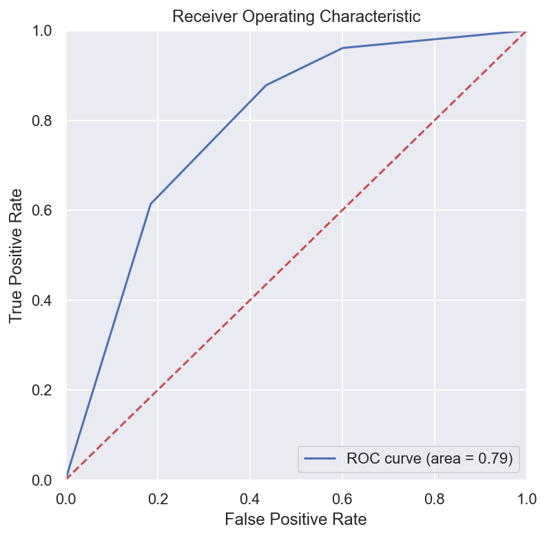

```python
print('\n"""""" DecisionTreeClassifier """"""')

print('\nSearch for optimal max_depth in DecisionTree, vary 2 to 10, using KFold(5) Cross Validation on train data')
kf = KFold(n_splits=5, random_state=21, shuffle=True)  #produce the k folds
d_scores = []
for d in range(2, 11):
    decisiontree = DecisionTreeClassifier(max_depth=d)
    cvs = cross_val_score(decisiontree, X_train, y_train, cv=kf, scoring='f1').mean()
    d_scores.append(cvs)
    print('{:.4f}'.format(cvs), end=", ")
print('optimal F1 score = {:.4f}'.format(max(d_scores)))   # 4 decimal pl
optimal_d = d_scores.index(max(d_scores))+2   # index 0 is for d=2
print('optimal max_depth =', optimal_d)

time1 = time.time()
decisiontree = DecisionTreeClassifier(max_depth=optimal_d)
model_report('DecisionTreeClassifier', decisiontree)

model_list.append('DecisionTreeClassifier')
f1_list.append(model_f1)
auc_list.append(model_auc)
ll_list.append(model_ll)
roc_auc_list.append(model_roc_auc)
time_list.append(time.time() - time1)
```

```
"""""" RandomForestClassifier """""" (quite slow)

Search for optimal n_estimators in RandomForest, vary 100 to 500, using KFold(5) Cross Validation on train data
100->0.5443, 150->0.5490, 200->0.5470, 250->0.5430, 300->0.5472, 350->0.5474, 400->0.5485, 450->0.5467, 500->0.5485, optimal F1 score = 0.5490
optimal n_estimators = 150

Search for OPTIMAL THRESHOLD, vary from 0.0001 to 0.9999, fit/predict on train/test data

Looping decimal place 1
0.000->0.4595,  0.100->0.5498,  0.200->0.5840,  0.300->0.6069,  0.400->0.5867,  0.500->0.5496,  0.600->0.4815,  0.700->0.3741,  0.800->0.2969,  0.900->0.1402,  1.000->0.0000,
Looping decimal place 2
0.200->0.5840,  0.210->0.5841,  0.220->0.5869,  0.230->0.5886,  0.240->0.5927,  0.250->0.5906,  0.260->0.5913,  0.270->0.5886,  0.280->0.5998,  0.290->0.6043,  0.300->0.6069,  0.310->0.6112,  0.320->0.6048,  0.330->0.6097,  0.340->0.6071,  0.350->0.6081,  0.360->0.6077,  0.370->0.6056,  0.380->0.602…
Looping decimal place 3
0.300->0.6069,  0.301->0.6069,  0.302->0.6069,  0.303->0.6069,  0.304->0.6069,  0.305->0.6069,  0.306->0.6069,  0.307->0.6112,  0.308->0.6112,  0.309->0.6112,  0.310->0.6112,  0.311->0.6112,  0.312->0.6112,  0.313->0.6112,  0.314->0.6048,  0.315->0.6048,  0.316->0.6048,  0.317->0.6048,  0.318->0.604…
optimal threshold = 0.307
RandomForestClassifier accuracy score is
Training: 99.79%
Test set: 77.29%

Adjust threshold to 0.25:
Precision: 0.4866,   Recall: 0.7513,   F1 Score: 0.5906
RandomForestClassifier confusion matrix:
 [[717 306]
 [ 96 290]]

Default threshold of 0.50:
Precision: 0.6051,   Recall: 0.4922,   F1 Score: 0.5429
RandomForestClassifier confusion matrix:
 [[899 124]
 [196 190]]

Adjust threshold to 0.75:
Precision: 0.7000,   Recall: 0.2176,   F1 Score: 0.3320
RandomForestClassifier confusion matrix:
 [[987  36]
 [302  84]]

Optimal threshold 0.307
Precision: 0.5397,   Recall: 0.7047,   F1 Score: 0.6112
RandomForestClassifier confusion matrix:
 [[791 232]
 [114 272]]
RandomForestClassifier Log-loss: 0.5001
RandomForestClassifier roc_auc_score: 0.6855
RandomForestClassifier AUC: 0.8065
```

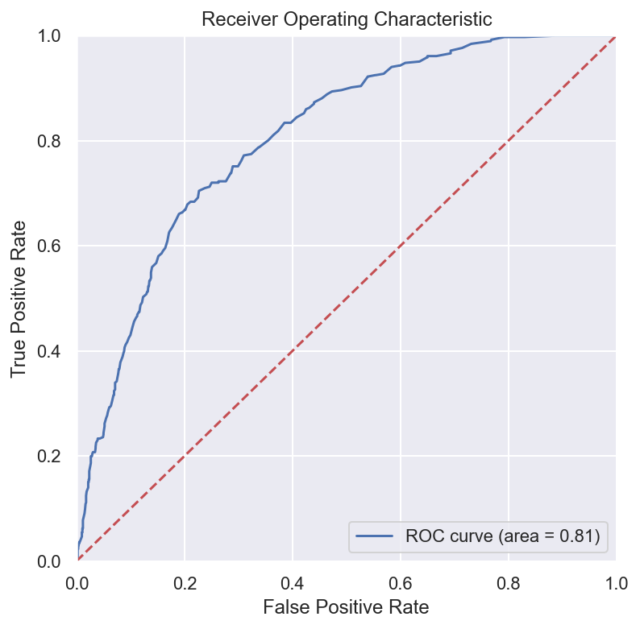

```python
print('\n"""""" RandomForestClassifier """""" (quite slow)')

print('\nSearch for optimal n_estimators in RandomForest, vary 100 to 500, using KFold(5) Cross Validation on train data')
kf = KFold(n_splits=5, random_state=21, shuffle=True)  #produce the k folds
score_list = []
n_list = []
for n in [100, 150, 200, 250, 300, 350, 400, 450, 500]:
    randomforest = RandomForestClassifier(n_estimators=n)
    cvs = (cross_val_score(randomforest, X_train, y_train, cv=kf, scoring='f1')).mean()
    score_list.append(cvs)
    n_list.append(n)
    print('{:.0f}->{:.4f}'.format(n, cvs), end=", ")   # display score in 4 decimal place
print('optimal F1 score = {:.4f}'.format(max(score_list)))
optimal_n = int(n_list[score_list.index(max(score_list))])
print('optimal n_estimators = {:.0f}'.format(optimal_n))

time1 = time.time()
randomforest = RandomForestClassifier(n_estimators=optimal_n)
model_report('RandomForestClassifier', randomforest)

model_list.append('RandomForestClassifier')
f1_list.append(model_f1)
auc_list.append(model_auc)
ll_list.append(model_ll)
roc_auc_list.append(model_roc_auc)
time_list.append(time.time() - time1)
```

```
"""""" LinearSVC """"""
LinearSVC accuracy score is
Training: 80.81%
Test set: 79.84%
              precision    recall  f1-score   support

           0       0.84      0.90      0.87      1023
           1       0.66      0.54      0.59       386

    accuracy                           0.80      1409
   macro avg       0.75      0.72      0.73      1409
weighted avg       0.79      0.80      0.79      1409

LinearSVC confusion matrix:
 [[918 105]
 [179 207]]
LinearSVC Log-loss: 6.9617
LinearSVC roc_auc_score: 0.7168
LinearSVC AUC: 0.7168
```

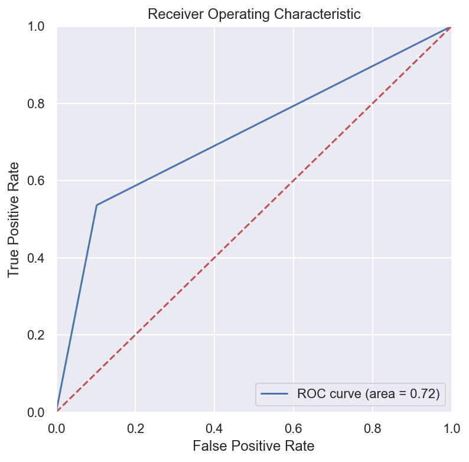

```python
print('\n"""""" LinearSVC """"""')
time1 = time.time()
linearsvc = LinearSVC()
# model_report('LinearSVC', linearsvc)   # model has no attribute 'predict_proba'
linearsvc.fit(X_train, y_train)
print('LinearSVC accuracy score is')
print('Training: {:.2f}%'.format(100*linearsvc.score(X_train, y_train)))  # score uses accuracy
print('Test set: {:.2f}%'.format(100*linearsvc.score(X_test, y_test)))   # should use cross validation

y_pred = linearsvc.predict(X_test)
print(metrics.classification_report(y_test, y_pred))
print('LinearSVC confusion matrix: \n', confusion_matrix(y_test, y_pred))

model_f1 = f1_score(y_test, y_pred)

model_ll = log_loss(y_test, y_pred)
print('LinearSVC Log-loss: {:.4f}'.format(model_ll))
model_roc_auc = roc_auc_score(y_test, y_pred)
print('LinearSVC roc_auc_score: {:.4f}'.format(model_roc_auc))
fpr, tpr, thresholds = roc_curve(y_test, y_pred)
model_auc = auc(fpr, tpr)
print('LinearSVC AUC: {:.4f}'.format(model_auc))

# plot the ROC curve
plt.figure(figsize = [6,6])
plt.plot(fpr, tpr, label='ROC curve (area = %0.2f)' % model_auc)
plt.plot([0, 1], [0, 1],'r--')
plt.xlim([0.0, 1.0])
plt.ylim([0.0, 1.0])
plt.xlabel('False Positive Rate')
plt.ylabel('True Positive Rate')
plt.title('Receiver Operating Characteristic')
plt.legend(loc="lower right")
# plt.savefig('roc_auc_score')
plt.show()

model_list.append('LinearSVC')
f1_list.append(model_f1)
auc_list.append(model_auc)
ll_list.append(model_ll)
roc_auc_list.append(model_roc_auc)
time_list.append(time.time() - time1)
```

```
"""""" SVC """""" (extremely slow)

Search for OPTIMAL THRESHOLD, vary from 0.0001 to 0.9999, fit/predict on train/test data

Looping decimal place 1
0.000->0.4301,  0.100->0.4390,  0.200->0.6371,  0.300->0.6182,  0.400->0.5668,  0.500->0.5369,  0.600->0.4856,  0.700->0.4205,  0.800->0.2635,  0.900->0.0103,  1.000->0.0000,
Looping decimal place 2
0.100->0.4390,  0.110->0.4469,  0.120->0.4609,  0.130->0.4954,  0.140->0.5299,  0.150->0.5687,  0.160->0.5977,  0.170->0.6128,  0.180->0.6199,  0.190->0.6311,  0.200->0.6371,  0.210->0.6279,  0.220->0.6292,  0.230->0.6220,  0.240->0.6295,  0.250->0.6248,  0.260->0.6236,  0.270->0.6215,  0.280->0.615…
Looping decimal place 3
0.190->0.6311,  0.191->0.6325,  0.192->0.6324,  0.193->0.6309,  0.194->0.6323,  0.195->0.6344,  0.196->0.6351,  0.197->0.6351,  0.198->0.6359,  0.199->0.6349,  0.200->0.6371,  0.201->0.6370,  0.202->0.6362,  0.203->0.6353,  0.204->0.6361,  0.205->0.6313,  0.206->0.6298,  0.207->0.6266,  0.208->0.625…
optimal threshold = 0.200
SVC accuracy score is
Training: 81.93%
Test set: 79.28%

Adjust threshold to 0.25:
Precision: 0.6058,   Recall: 0.6451,   F1 Score: 0.6248
SVC confusion matrix:
 [[861 162]
 [137 249]]

Default threshold of 0.50:
Precision: 0.6767,   Recall: 0.4663,   F1 Score: 0.5521
SVC confusion matrix:
 [[937  86]
 [206 180]]

Adjust threshold to 0.75:
Precision: 0.7153,   Recall: 0.2668,   F1 Score: 0.3887
SVC confusion matrix:
 [[982  41]
 [283 103]]

Optimal threshold 0.200
Precision: 0.5680,   Recall: 0.7254,   F1 Score: 0.6371
SVC confusion matrix:
 [[810 213]
 [106 280]]
SVC Log-loss: 0.4694
SVC roc_auc_score: 0.6911
SVC AUC: 0.7981
```

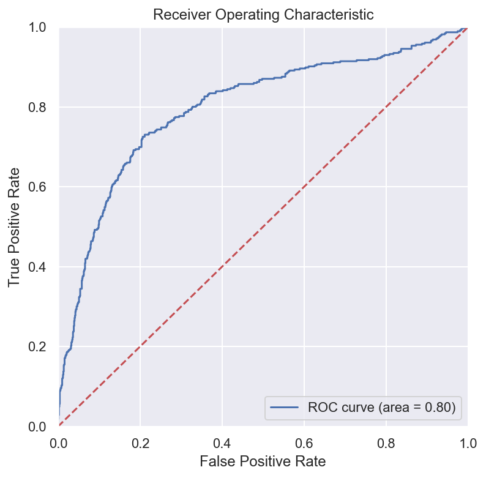

```python
print('\n"""""" SVC """""" (extremely slow)')
time1 = time.time()
svc = SVC(gamma='scale', probability=True)
model_report('SVC', svc)

model_list.append('SVC')
f1_list.append(model_f1)
auc_list.append(model_auc)
ll_list.append(model_ll)
roc_auc_list.append(model_roc_auc)
# time_list.append(time.time() - time1)   # use this line for actual time spent, or
time_list.append(0)
```

## Classification - Model Comparison

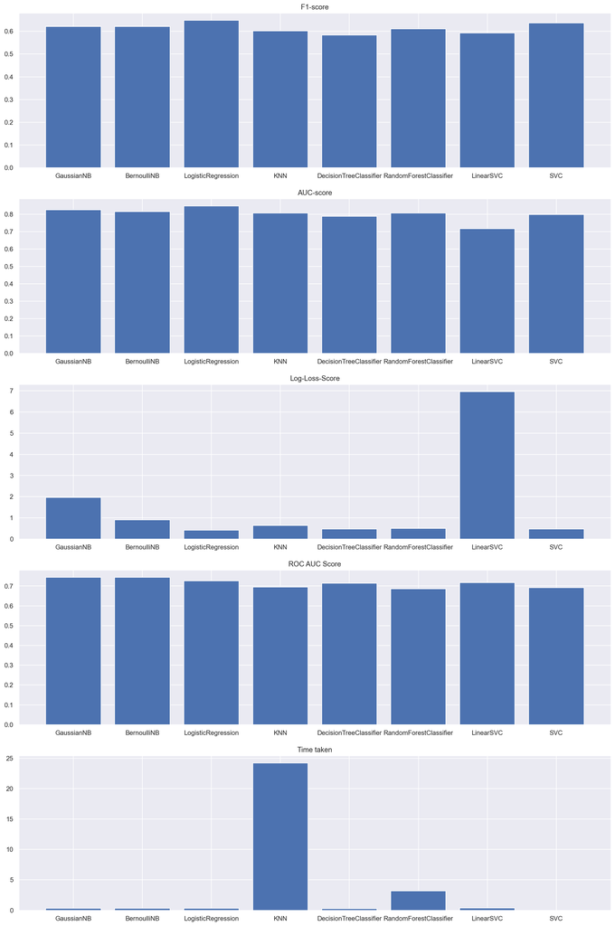

```python
## plot the classification report scores
fig, ax = plt.subplots(5, 1, figsize=(18, 28))
# fig.set_figwidth(10)
# fig.set_figheight(6)
# fig.suptitle('Main Title',fontsize = 16)
ax[0].bar(model_list, f1_list)
ax[0].set_title('F1-score')
ax[1].bar(model_list, auc_list)
ax[1].set_title('AUC-score')
ax[2].bar(model_list, ll_list)
ax[2].set_title('Log-Loss-Score')
ax[3].bar(model_list, roc_auc_list)
ax[3].set_title('ROC AUC Score')
ax[4].bar(model_list, time_list)
ax[4].set_title('Time taken')
# Fine-tune figure: make subplots farther from each other, or nearer to each other.
fig.subplots_adjust(hspace=0.2, wspace=0.2)
```

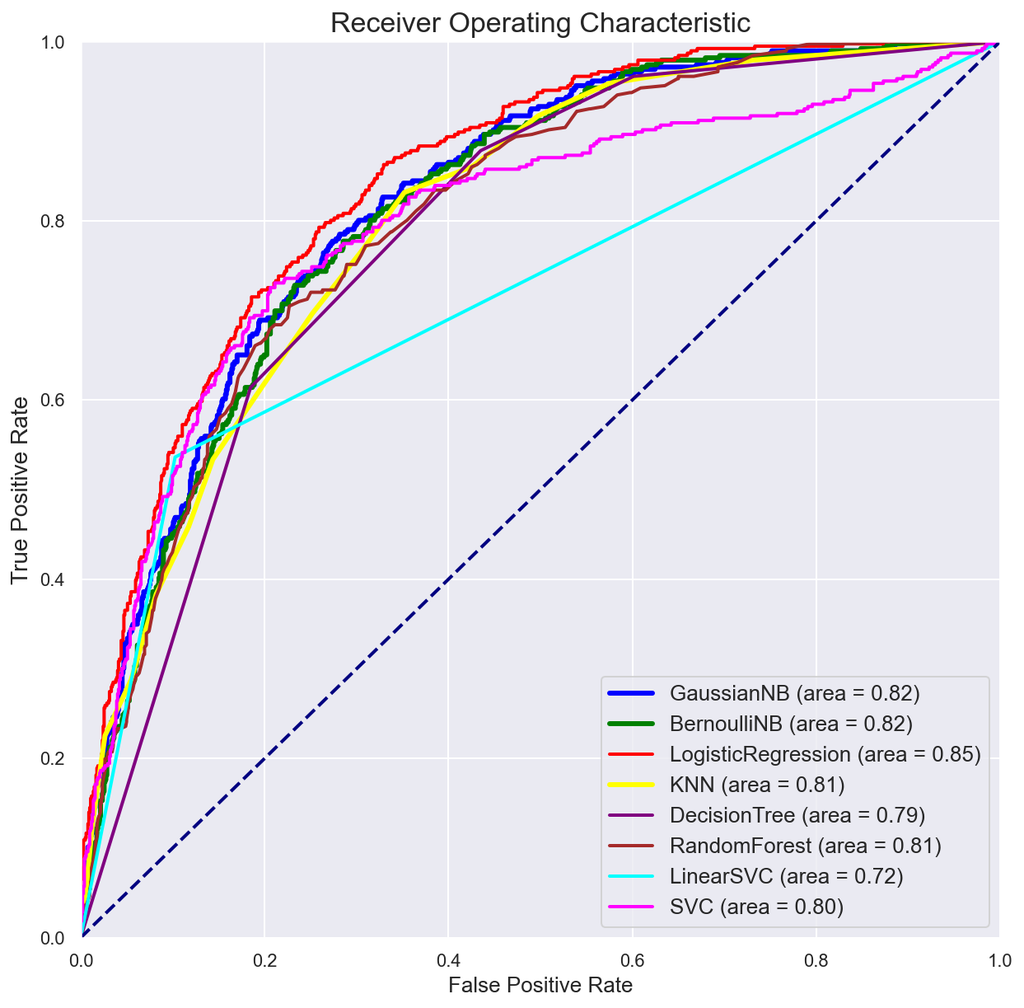

```python
# plot the ROC curves
plt.figure(figsize=(10,10))

y_pred = gnb.predict_proba(X_test)[:,1]
fpr, tpr, thresholds = roc_curve(y_test, y_pred)
plt.plot(fpr, tpr, color='blue',
        lw=3, label='GaussianNB (area = %0.2f)' % auc_list[0])

y_pred = bnb.predict_proba(X_test)[:,1]
fpr, tpr, thresholds = roc_curve(y_test, y_pred)
plt.plot(fpr, tpr, color='green',
        lw=3, label='BernoulliNB (area = %0.2f)' % auc_list[1])

y_pred = logit.predict_proba(X_test)[:,1]
fpr, tpr, thresholds = roc_curve(y_test, y_pred)
plt.plot(fpr, tpr, color='red',
        lw=2, label='LogisticRegression (area = %0.2f)' % auc_list[2])

y_pred = knn.predict_proba(X_test)[:,1]
fpr, tpr, thresholds = roc_curve(y_test, y_pred)
plt.plot(fpr, tpr, color='yellow',
        lw=3, label='KNN (area = %0.2f)' % auc_list[3])

y_pred = decisiontree.predict_proba(X_test)[:,1]
fpr, tpr, thresholds = roc_curve(y_test, y_pred)
plt.plot(fpr, tpr, color='purple',
        lw=2, label='DecisionTree (area = %0.2f)' % auc_list[4])

y_pred = randomforest.predict_proba(X_test)[:,1]
fpr, tpr, thresholds = roc_curve(y_test, y_pred)
plt.plot(fpr, tpr, color='brown',
        lw=2, label='RandomForest (area = %0.2f)' % auc_list[5])

y_pred = linearsvc.predict(X_test)
fpr, tpr, thresholds = roc_curve(y_test, y_pred)
plt.plot(fpr, tpr, color='cyan',
        lw=2, label='LinearSVC (area = %0.2f)' % auc_list[6])

y_pred = svc.predict_proba(X_test)[:,1]
fpr, tpr, thresholds = roc_curve(y_test, y_pred)
plt.plot(fpr, tpr, color='magenta',
        lw=2, label='SVC (area = %0.2f)' % auc_list[7])

plt.plot([0, 1], [0, 1], color='navy', lw=2, linestyle='--')
plt.xlim([0.0, 1.0])
plt.ylim([0.0, 1.0])
plt.xlabel('False Positive Rate', fontsize=13)
plt.ylabel('True Positive Rate', fontsize=14)
plt.title('Receiver Operating Characteristic', fontsize=17)
plt.legend(loc='lower right', fontsize=13)
plt.show()
```

```python
# Additional Analysis.
# see how logistic regression confusion matrix varies with threshold
def make_confusion_matrix(model, threshold=0.5):
    # Predict class 1 if probability of being in class 1 is greater than threshold
    # (model.predict(X_test) does this automatically with a threshold of 0.5)
    y_pred = (logit.predict_proba(X_test)[:, 1] >= threshold)
    conf = confusion_matrix(y_test, y_pred)
    plt.figure(figsize = [5,5])
    sns.heatmap(conf, cmap=plt.cm.Blues, annot=True, square=True, fmt='d',
           xticklabels=['no churn', 'churn'],
           yticklabels=['no churn', 'churn'])
    plt.xlabel('prediction')
    plt.ylabel('actual')
# Let's see how our confusion matrix changes with changes to the cutoff!
from ipywidgets import interactive, FloatSlider
logit = LogisticRegression(C = optimal_c)
logit.fit(X_train, y_train)
interactive(lambda threshold: make_confusion_matrix(logit, threshold), threshold=(0.0,1.0,0.01))
```

## Classification - Conclusion

### Model Selection

After feature selection, we ran the below 8 models, trained and optimized them.

1. Gaussian NB
2. Bernoulli NB
3. Logistric Regression
4. KNN
5. Decision Tree
6. RandomForest
7. LinearSVC
8. SVC

### Metrics

We have used 3 metrics for model selection. The below metrics are chosen because our goal is to predict customer who are likely to churn with better accuracy.

1. F-Score - which tells the balance between Precision and Recall rates trade off.
2. ROC - which is a relationship between true positive rate and false positive rate.
3. Log Loss - which measures uncertainity.

### Final Model

Logistic Regression performed better than the rest. It had better F1-scores, highest ROC value and one with lowest loss function.

### Deployment

These models can generate a list of customers who are most vulnerable to churn, so that a focused customer retention program can be prioritized on them.